# EEMB 179: Week 4: Homework

4. Run three simulations to check your answers for Part 3. For each, make an incidence diagram (total of 3 incidence diagrams) comparing the unvaccinated scenario (using a black line) with the vaccinated scenario (using a blue line). Don’t forget to (1) label your plots so that we know which corresponds to which scenario, and (2) include a legend indicating which line corresponds to vaccinated vs. unvaccinated.

[figure not shown]

[output not shown]

[figure not shown]

```r
par(mfcol = c(3, 1))
#SCENARIO A
VA <- N*p_crit.a
S0.v <- N - VA - I0


N.simu4.a <- NaN*tset; N.simu4.a[1] <- N
S.simu4.a <- NaN*tset; S.simu4.a[1] <- S0.v
I.simu4.a <- NaN*tset; I.simu4.a[1] <- I0
R.simu4.a <- NaN*tset; R.simu4.a[1] <- N - I0 - S0.v - VA

for(i in 2:length(tset)){
    dt <- tset[i]-tset[i-1]
    S.4a <- S.simu4.a[i-1]
    I.4a <- I.simu4.a[i-1]
    R.4a <- R.simu4.a[i-1]
    dS.4a <- (-beta*S.4a*I.4a)*dt
    dI.4a <- (beta*S.4a*I.4a-gamma*I.4a)*dt
    dR.4a <- (gamma*I.4a)*dt
    dN.4a <- dS.4a+dI.4a+dR.4a
    S.simu4.a[i] <- S.4a + dS.4a
    I.simu4.a[i] <- I.4a + dI.4a
    R.simu4.a[i] <- R.4a + dR.4a
    N.simu4.a[i] <- N + dN.4a
}

plot(x = tset, y = I.simu.a, type = 'l', las = 1, col = 'black', xlab = 'Time', ylab='Incidence', main= 'Scenario A',  ylim= c(0,90))
lines(x = tset, y = I.simu4.a, col = 'blue')
legend(x = max(tset)*0.6, y = 50, legend = c('Unvaccinated','Vaccinated'), lwd = 2, col = c('black', 'blue'))

#SCENARIO B

VB <- N*p_crit.b
S0.vb <- N - VB - I0


N.simu4.b <- NaN*tset; N.simu4.b[1] <- N
S.simu4.b <- NaN*tset; S.simu4.b[1] <- S0.vb
I.simu4.b <- NaN*tset; I.simu4.b[1] <- I0
R.simu4.b <- NaN*tset; R.simu4.b[1] <- N - I0 - S0.vb - VA

for(i in 2:length(tset)){
    dt <- tset[i]-tset[i-1]
    S.4b <- S.simu4.b[i-1]
    I.4b <- I.simu4.b[i-1]
    R.4b <- R.simu4.b[i-1]
    dS.4b <- (-beta.b*S.4b*I.4b)*dt
    dI.4b <- (beta.b*S.4b*I.4b-gamma*I.4b)*dt
    dR.4b <- (gamma*I.4b)*dt
    dN.4b <- dS.4b+dI.4b+dR.4b
    S.simu4.b[i] <- S.4b + dS.4b
    I.simu4.b[i] <- I.4b + dI.4b
    R.simu4.b[i] <- R.4b + dR.4b
    N.simu4.b[i] <- N + dN.4b
}

plot(x = tset, y = I.simu.b, type = 'l', las = 1, col = 'black', xlab = 'Time', ylab='Incidence', main= 'Scenario B', ylim= c(0,90))
lines(x = tset, y = I.simu4.b, col = 'blue')
legend(x = max(tset)*0.6, y = 50, legend = c('Unvaccinated','Vaccinated'), lwd = 2, col = c('black', 'blue'))
?ylim
#SCENARIO C

VC <- N*p_crit.c
S0.vc <- N - VC - I0


N.simu4.c <- NaN*tset; N.simu4.c[1] <- N
S.simu4.c <- NaN*tset; S.simu4.c[1] <- S0.vb
I.simu4.c <- NaN*tset; I.simu4.c[1] <- I0
R.simu4.c <- NaN*tset; R.simu4.c[1] <- N - I0 - S0.vb - VA

for(i in 2:length(tset)){
    dt <- tset[i]-tset[i-1]
    S.4c <- S.simu4.c[i-1]
    I.4c <- I.simu4.c[i-1]
    R.4c <- R.simu4.c[i-1]
    dS.4c <- (-beta*S.4c*I.4c)*dt
    dI.4c <- (beta*S.4c*I.4c-gamma.c*I.4c)*dt
    dR.4c <- (gamma.c*I.4c)*dt
    dN.4c <- dS.4c+dI.4c+dR.4c
    S.simu4.c[i] <- S.4c + dS.4c
    I.simu4.c[i] <- I.4c + dI.4c
    R.simu4.c[i] <- R.4c + dR.4c
    N.simu4.c[i] <- N + dN.4c
}

plot(x = tset, y = I.simu.c, type = 'l', las = 1, col = 'black', xlab = 'Time', ylab='Incidence', main= 'Scenario C', ylim= c(0,90))
lines(x = tset, y = I.simu4.c, col = 'blue')
legend(x = max(tset)*0.5, y = 30, legend = c('Unvaccinated','Vaccinated'), lwd = 2, col = c('black', 'blue'))
```

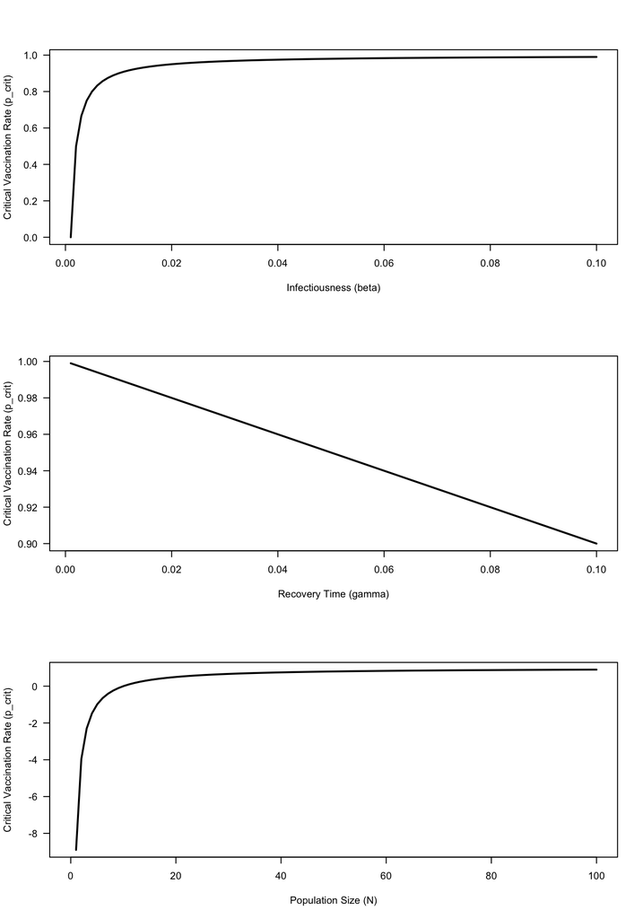

```r
par( mfrow= c(3,1))
p_crit_set <- 1 - 1/R0_set

# p_crit x Beta
plot(x = beta_set, y = p_crit_set, type = 'l', xlab = 'Infectiousness (beta)', ylab = 'Critical Vaccination Rate (p_crit)', las = 1, lwd = 2)

p_critg_set <- 1 - 1/R0g_set

# p_crit x Gamma
plot(x = gamma_set, y = p_critg_set, type = 'l', xlab = 'Recovery Time (gamma)', ylab = 'Critical Vaccination Rate (p_crit)', las = 1, lwd = 2)

p_critn_set <- 1 - 1/R0n_set
# p_crit x Pop Size
plot(x = Nset, y = p_critn_set, type = 'l', xlab = 'Population Size (N)', ylab = 'Critical Vaccination Rate (p_crit)', las = 1, lwd = 2)
```

The pcrit values are negative for p_crit x Pop Size because at a low population size (N<10) with a beta of 0.01 and gamma of 0.1 the R0 value is less than 1. So, pcrit = 1 - 1/ RO would be a negative number.

/6 points for explanation of how R_0 and p depend upon infectiousness, recovery time, and population size.

/6 point per simulation line

/6 point per set of axes

/2 point for explanation of negative p_crit values in answer to 5c

= /20 points total (6 plots)